# Final-Project

## Preamble

In this lab, you will explore data from NASA’s Exoplanet Archive. This archive contains information about confirmed exoplanets discovered outside our Solar System. This dataset includes information about confirmed exoplanets, such as planet name, host star, discovery method, discovery year, discovery facility, planet radius, planet mass, orbital period, star characteristics, and distance from Earth.

[NASA Exoplanet Archive Data Column Definitions](https://exoplanetarchive.ipac.caltech.edu/docs/API_PS_columns.html)

**Variables needed in this lab**

| Variable | Meaning | How it is used in this lab |
| --- | --- | --- |
| `discoverymethod` | Method used to detect the exoplanet | Compares discovery techniques and summarizes discovery outcomes |
| `disc_year` | Year the planet discovery was announced | Tracks how discoveries changed over time |
| `disc_facility` | Facility, telescope, or mission credited with discovery | Compares discovery sources |
| `pl_rade` | Planet radius in Earth radii | Used for size classifications and radius-mass analyses |
| `pl_bmasse` | Planet mass in Earth masses | Used for mass classifications and radius-mass analyses |
| `pl_orbper` | Orbital period in days | Compares how long planets take to orbit their host stars |
| `pl_eqt` | Planet equilibrium temperature in Kelvin | Used to identify simple rocky-zone candidates |
| `sy_dist` | Distance from Earth in parsecs | Examines planetary system distance and Earth-like rankings |
| `sy_pnum` | Number of planets in the planetary system | Used in the distance-versus-planet-count analysis |
| `sy_snum` | Number of stars in the system | Used in the simulation question |
| `st_teff` | Stellar effective temperature in Kelvin | Included in the missing-data analysis |
| `st_mass` | Stellar mass in solar masses | Included in the missing-data analysis |
| `pl_name` | Planet name | Used to identify planets in summary tables |
| `hostname` | Name of the host star | Provides context for planet-level summaries |

## Loading Libraries

```r
library(tidyverse)
library(knitr)
```

## Data

[Planetary Systems Composite Data Download](https://exoplanetarchive.ipac.caltech.edu/cgi-bin/TblView/nph-tblView?app=ExoTbls&config=PSCompPars)

```r
PSCD <- read.csv("Planetar_Systems_CompositeData.csv",
                comment.char = "#")
```

**1. Explore the discovery methods used in the dataset. Create a summary showing how many planets were discovered by each method and visualize the results with an informative bar chart.**

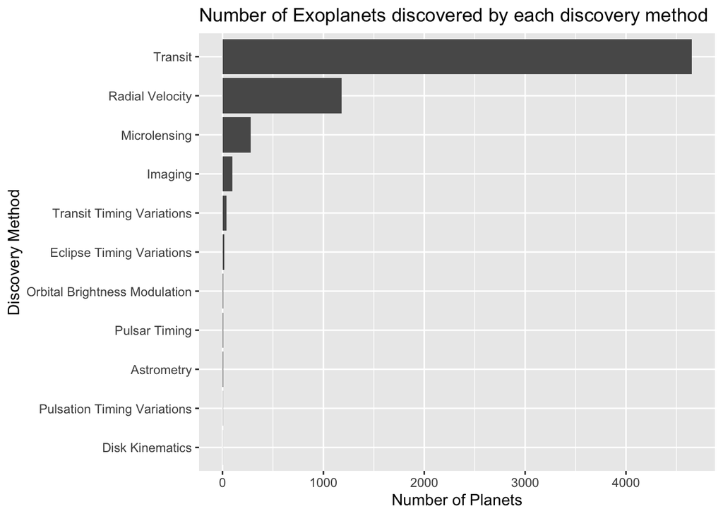

```r
count <- PSCD |>
  count(discoverymethod)

ggplot(count,
       aes(x = reorder(discoverymethod, n),
              y = n)) +
         geom_col() +
         labs(title = "Number of Exoplanets discovered by each discovery method",
              x = "Discovery Method",
              y = "Number of Planets") +
  coord_flip()
```

**2. Create a function that classifies exoplanets into size categories using planet radius (`pl_rade`). Use the function to summarize the dataset and identify the most common size categories.**

```r
#Use pl_rade

size <- function(radius) {
  if(is.na(radius)){
    return("Unknown radius")
  } else if (radius < 1.25) {
    return("Similar size to Earth")
  } else if(radius < 6){
    return ("Similar size to Neptune")
  } else{
    return("Similar size to Jupiter or larger")
  }
}

PSCD$planet_type <- sapply(PSCD$pl_rade, size)
table(PSCD$planet_type)
```

```
            Similar size to Earth Similar size to Jupiter or larger
                              576                              2086
          Similar size to Neptune                    Unknown radius
                             3579                                50
```

**3. How are the different discovery methods related to a planet’s proximity from Earth? Make an informative bar chart displaying the difference in the most common distances between each method.**

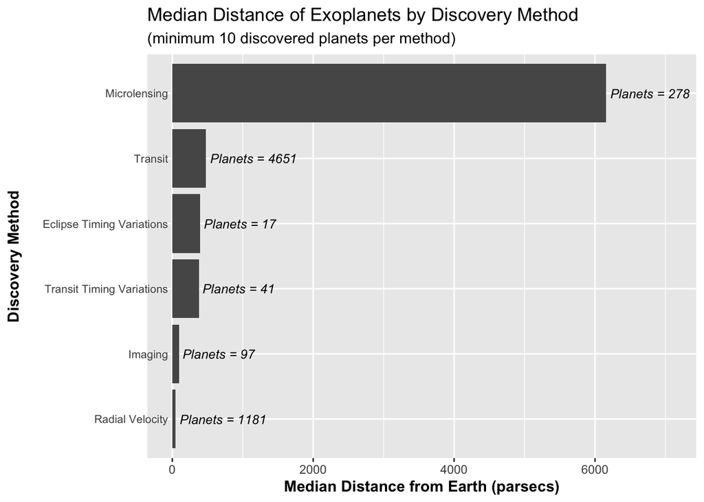

```r
method_profile <- function(method) {
  PSCD |>
    filter(discoverymethod == method) |>
    summarize(
      discoverymethod = method,
      number_of_planets = n(),
      median_distance = median(sy_dist, na.rm = TRUE)
    )
}

method_table <- unique(PSCD$discoverymethod) |>
  map_dfr(method_profile) |>
  filter(number_of_planets >= 10) |>
  arrange(median_distance) |>
  mutate(discoverymethod = factor(discoverymethod, levels = discoverymethod))

ggplot(method_table,
       aes(x = median_distance,
           y = discoverymethod)) +
  geom_col(fill = "gray34") +
  geom_text(aes(label = paste("Planets =", number_of_planets)),
            hjust = -0.05,
            size = 3.25,
            fontface = "italic") +
  expand_limits(x = max(method_table$median_distance) * 1.15) +
  labs(
    title = "Median Distance of Exoplanets by Discovery Method",
    subtitle = "(minimum 10 discovered planets per method)",
    x = "Median Distance from Earth (parsecs)",
    y = "Discovery Method"
  ) +
  theme(axis.ticks.y = element_blank()) +
  theme(axis.title.y = element_text(face = 'bold', margin = margin(r = 15)),
        axis.title.x = element_text(face = 'bold'),
        axis.text.y = element_text(size = 8, margin = margin(r = -15))
)
```

**4. Investigate whether the distance of a planetary system from Earth (`sy_dist`) is related to the number of planets detected in that system (`sy_pnum`). Use a linear regression model, summarize the model results, and visualize the relationship.**

sy_pnum = 1.864 - .0001384(sy_dist) Due to a p-value of < 2 × 10⁻¹⁶) there is a statistically significant negative relationship between the distance of a planetary system and the number of planets detected. The effect is weak as R^2 = 0.021

```r
dist_planets_lm <- lm(sy_pnum ~ sy_dist,
                    data = PSCD)
summary(dist_planets_lm)
```

```
Call:
lm(formula = sy_pnum ~ sy_dist, data = PSCD)

Residuals:
    Min      1Q  Median      3Q     Max
-0.8633 -0.8186 -0.6791  0.2430  6.2537

Coefficients:
              Estimate Std. Error t value Pr(>|t|)
(Intercept)  1.864e+00  1.670e-02  111.63   <2e-16 ***
sy_dist     -1.384e-04  1.192e-05  -11.61   <2e-16 ***
---
Signif. codes:  0 '***' 0.001 '**' 0.01 '*' 0.05 '.' 0.1 ' ' 1

Residual standard error: 1.142 on 6262 degrees of freedom
  (27 observations deleted due to missingness)
Multiple R-squared:  0.02108,   Adjusted R-squared:  0.02092
F-statistic: 134.8 on 1 and 6262 DF,  p-value: < 2.2e-16
```

```r
broom::tidy(dist_planets_lm)
```

```
# A tibble: 2 × 5
  term         estimate std.error statistic  p.value
  <chr>           <dbl>     <dbl>     <dbl>    <dbl>
1 (Intercept)  1.86     0.0167        112.  0
2 sy_dist     -0.000138 0.0000119     -11.6 7.48e-31
```

```r
broom::glance(dist_planets_lm) |>
  knitr::kable()
```

| r.squared | adj.r.squared | sigma | statistic | p.value | df | logLik | AIC | BIC | deviance | df.residual | nobs |
| --- | --- | --- | --- | --- | --- | --- | --- | --- | --- | --- | --- |
| 0.0210759 | 0.0209196 | 1.142229 | 134.8189 | 0 | 1 | -9720.225 | 19446.45 | 19466.68 | 8169.943 | 6262 | 6264 |

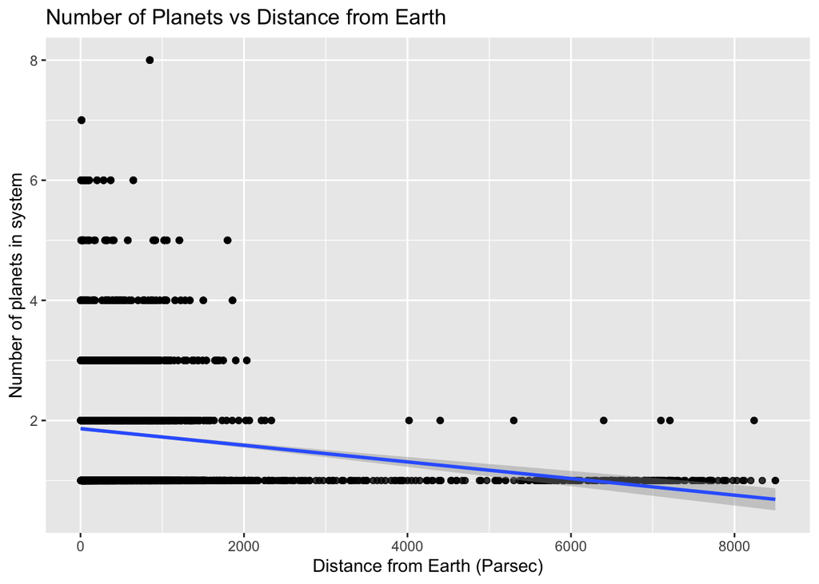

```r
ggplot(PSCD,
       aes(x = sy_dist,
           y = sy_pnum)) +
  geom_point(alpha = .8) +
  geom_smooth(method = "lm") +
  labs(title = "Number of Planets vs Distance from Earth",
       x = "Distance from Earth (Parsec)",
       y = "Number of planets in system")
```

**5. Create a function that classifies exoplanets into mass categories using planet mass (`pl_bmasse`) and familiar Solar System planets as reference points. Use the function to summarize the distribution of mass categories in the dataset.**

```r
mass_category <- function(mass) {
  if (is.na(mass)){
    return(NA)
  } else if (mass < .06) {
      return("Similar to Mercury")
  } else if (mass < .11){
      return("Similar to Mars")
  } else if (mass < .82){
      return("Similar to Venus")
  } else if (mass < 1.2){
      return("Similar to Earth")
  } else if (mass < 14.5){
      return("Similar to Uranus")
  } else if (mass < 17.2){
      return("Similar to Neptune")
  } else if (mass < 95.2){
      return("Similar to Saturn")
  } else if (mass < 317.8){
      return("Similar to Jupiter")
  }else {
      return("Out of Scale")
  }
}

PSCD$mass_class <- map_chr(PSCD$pl_bmasse, mass_category)
table(PSCD$mass_class)
```

```
      Out of Scale   Similar to Earth Similar to Jupiter    Similar to Mars
              1241                 94                583                  7
Similar to Mercury Similar to Neptune  Similar to Saturn  Similar to Uranus
                 4                137                629               3399
  Similar to Venus
               166
```

**6. Examine the relationship between exoplanet radius (`pl_rade`) and exoplanet mass (`pl_bmasse`). Fit a linear regression model, summarize the results, and create a visualization that helps interpret the relationship.** pl_bmasse = -160.173 + 95.270(pl_rade)

The regression indicates a statistically significant (p < 2.2 × 10⁻¹⁶) relationship between exoplanet mass and radius. The regression model has an R^2 of .207 which indicates that about 20.7% of the variation in exoplanet mass can be explained by the differences in exoplanet radius.

```r
mass_radius_lm <- lm(pl_bmasse ~ pl_rade,
                     data = PSCD)

summary(mass_radius_lm)
```

```
Call:
lm(formula = pl_bmasse ~ pl_rade, data = PSCD)

Residuals:
    Min      1Q  Median      3Q     Max
-4506.7  -262.9   -63.4    22.9  8561.3

Coefficients:
            Estimate Std. Error t value Pr(>|t|)
(Intercept) -160.173     18.639  -8.593   <2e-16 ***
pl_rade       95.270      2.362  40.332   <2e-16 ***
---
Signif. codes:  0 '***' 0.001 '**' 0.01 '*' 0.05 '.' 0.1 ' ' 1

Residual standard error: 1002 on 6215 degrees of freedom
  (74 observations deleted due to missingness)
Multiple R-squared:  0.2074,    Adjusted R-squared:  0.2073
F-statistic:  1627 on 1 and 6215 DF,  p-value: < 2.2e-16
```

```r
broom::tidy(mass_radius_lm)
```

```
# A tibble: 2 × 5
  term        estimate std.error statistic   p.value
  <chr>          <dbl>     <dbl>     <dbl>     <dbl>
1 (Intercept)   -160.      18.6      -8.59 1.06e- 17
2 pl_rade         95.3      2.36     40.3  3.85e-316
```

```r
broom::glance(mass_radius_lm) |>
  knitr::kable()
```

| r.squared | adj.r.squared | sigma | statistic | p.value | df | logLik | AIC | BIC | deviance | df.residual | nobs |
| --- | --- | --- | --- | --- | --- | --- | --- | --- | --- | --- | --- |
| 0.2074418 | 0.2073143 | 1001.57 | 1626.696 | 0 | 1 | -51775.81 | 103557.6 | 103577.8 | 6234530324 | 6215 | 6217 |

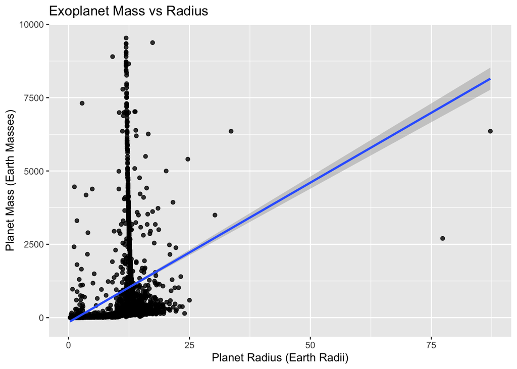

```r
ggplot(PSCD,
       aes(x = pl_rade,
           y = pl_bmasse)) +
  geom_point(alpha = 0.8) +
  geom_smooth(method = "lm") +
  labs(
    title = "Exoplanet Mass vs Radius",
    x = "Planet Radius (Earth Radii)",
    y = "Planet Mass (Earth Masses)"
  )
```

**7. How have exoplanet discoveries changed over time? Create a line chart showing the number of planets discovered each year, and make a table of the five years with the most discoveries.**

```r
discoveries_by_year <- PSCD |>
  filter(!is.na(disc_year)) |>
  count(disc_year, name = "planets_discovered") |>
  arrange(disc_year)

top_discovery_years <- discoveries_by_year |>
  arrange(desc(planets_discovered)) |>
  slice_head(n = 5)

top_discovery_years |>
  kable(
    col.names = c("Discovery Year", "Planets Discovered"),
    caption = "Five years with the most exoplanet discoveries"
  )
```

Five years with the most exoplanet discoveries

| Discovery Year | Planets Discovered |
| --- | --- |
| 2016 | 1504 |
| 2014 | 869 |
| 2021 | 564 |
| 2022 | 368 |
| 2023 | 323 |

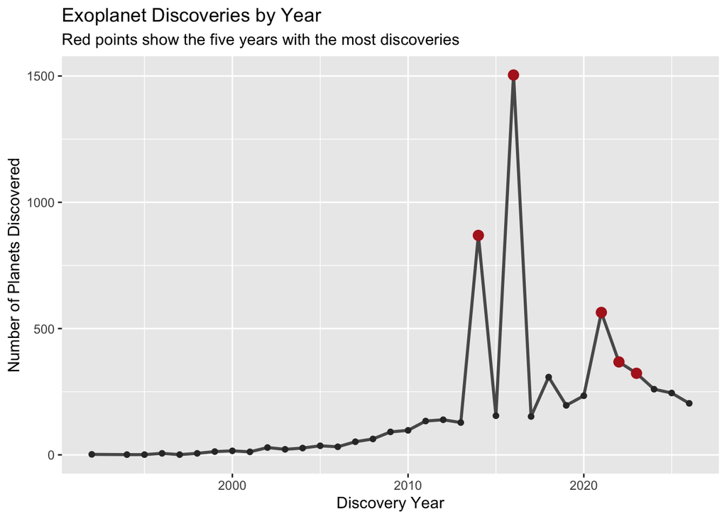

```r
ggplot(discoveries_by_year,
       aes(x = disc_year,
           y = planets_discovered)) +
  geom_line(color = "gray35", linewidth = 1) +
  geom_point(color = "gray20") +
  geom_point(data = top_discovery_years,
             color = "firebrick",
             size = 3) +
  labs(
    title = "Exoplanet Discoveries by Year",
    subtitle = "Red points show the five years with the most discoveries",
    x = "Discovery Year",
    y = "Number of Planets Discovered"
  )
```

The discovery counts are not evenly spread across time. The table identifies the largest discovery years, and the plot shows the overall increase in confirmed exoplanets after major survey missions began finding large numbers of planets.

**8. Create a function that identifies simple rocky-zone candidates. Classify a planet as a `"Rocky-zone candidate"` if its radius is between 0.5 and 2 Earth radii and its equilibrium temperature is between 180 K and 310 K. Use the function to summarize the dataset and display the 10 closest candidates to Earth.**

```r
rocky_zone_class <- function(radius, temp) {
  if (is.na(radius) | is.na(temp)) {
    return("Missing information")
  } else if (radius >= 0.5 & radius <= 2 & temp >= 180 & temp <= 310) {
    return("Rocky-zone candidate")
  } else {
    return("Not candidate")
  }
}

PSCD_candidate <- PSCD |>
  mutate(
    rocky_zone_candidate = map2_chr(pl_rade, pl_eqt, rocky_zone_class)
  )

candidate_summary <- PSCD_candidate |>
  count(rocky_zone_candidate, name = "number_of_planets") |>
  mutate(percent_of_dataset = 100 * number_of_planets / sum(number_of_planets)) |>
  arrange(desc(number_of_planets))

candidate_summary |>
  kable(
    digits = 2,
    col.names = c("Candidate Category", "Number of Planets", "Percent of Dataset"),
    caption = "Simple rocky-zone candidate classification"
  )
```

Simple rocky-zone candidate classification

| Candidate Category | Number of Planets | Percent of Dataset |
| --- | --- | --- |
| Not candidate | 4627 | 73.55 |
| Missing information | 1613 | 25.64 |
| Rocky-zone candidate | 51 | 0.81 |

```r
PSCD_candidate |>
  filter(rocky_zone_candidate == "Rocky-zone candidate") |>
  arrange(sy_dist) |>
  select(pl_name, hostname, discoverymethod, disc_year, pl_rade, pl_eqt, sy_dist) |>
  slice_head(n = 10) |>
  kable(
    digits = 2,
    col.names = c("Planet", "Host Star", "Discovery Method", "Discovery Year",
                  "Radius (Earth Radii)", "Equilibrium Temp (K)",
                  "Distance (Parsecs)"),
    caption = "Ten closest simple rocky-zone candidates"
  )
```

Ten closest simple rocky-zone candidates

| Planet | Host Star | Discovery Method | Discovery Year | Radius (Earth Radii) | Equilibrium Temp (K) | Distance (Parsecs) |
| --- | --- | --- | --- | --- | --- | --- |
| Proxima Cen b | Proxima Cen | Radial Velocity | 2016 | 1.02 | 218.0 | 1.30 |
| Proxima Cen d | Proxima Cen | Radial Velocity | 2025 | 0.69 | 282.0 | 1.30 |
| Ross 128 b | Ross 128 | Radial Velocity | 2017 | 1.11 | 301.0 | 3.37 |
| Teegarden’s Star b | Teegarden’s Star | Radial Velocity | 2019 | 1.05 | 277.0 | 3.83 |
| Teegarden’s Star c | Teegarden’s Star | Radial Velocity | 2019 | 1.02 | 209.0 | 3.83 |
| GJ 1002 b | GJ 1002 | Radial Velocity | 2022 | 1.03 | 230.9 | 4.85 |
| GJ 1002 c | GJ 1002 | Radial Velocity | 2022 | 1.10 | 181.7 | 4.85 |
| GJ 251 c | GJ 251 | Radial Velocity | 2025 | 1.80 | 216.0 | 5.58 |
| Wolf 1069 b | Wolf 1069 | Radial Velocity | 2023 | 1.08 | 250.1 | 9.58 |
| L 98-59 f | L 98-59 | Radial Velocity | 2025 | 1.48 | 285.0 | 10.62 |

This is only a simple classroom classification, not a scientific claim that the planets are habitable. It is still useful because it combines two variables and gives a smaller group of planets that students can investigate more carefully.

**9. Write a data-frame function that summarizes a numeric variable by discovery method. Use your function to compare orbital periods across discovery methods with at least 20 planets that have orbital-period data.**

```r
method_numeric_summary <- function(df, variable, min_planets = 20) {
  if (!is.data.frame(df)) {
    stop("The first input must be a data frame.")
  }

  if (!is.numeric(min_planets) | length(min_planets) != 1 | min_planets <= 0) {
    stop("min_planets must be one positive number.")
  }

  df |>
    filter(!is.na({{ variable }}),
           !is.na(discoverymethod)) |>
    group_by(discoverymethod) |>
    summarize(
      number_of_planets = n(),
      q1 = quantile({{ variable }}, 0.25, na.rm = TRUE),
      median_value = median({{ variable }}, na.rm = TRUE),
      q3 = quantile({{ variable }}, 0.75, na.rm = TRUE),
      .groups = "drop"
    ) |>
    filter(number_of_planets >= min_planets) |>
    arrange(median_value)
}

orbital_period_summary <- method_numeric_summary(PSCD, pl_orbper, min_planets = 20)

orbital_period_summary |>
  kable(
    digits = 2,
    col.names = c("Discovery Method", "Number of Planets", "Q1",
                  "Median Orbital Period", "Q3"),
    caption = "Orbital-period summaries by discovery method"
  )
```

Orbital-period summaries by discovery method

| Discovery Method | Number of Planets | Q1 | Median Orbital Period | Q3 |
| --- | --- | --- | --- | --- |
| Transit | 4651 | 3.81 | 8.01 | 18.80 |
| Transit Timing Variations | 41 | 9.34 | 30.36 | 75.73 |
| Radial Velocity | 1181 | 21.20 | 298.20 | 1121.79 |
| Imaging | 25 | 10037.50 | 33000.00 | 117000.00 |

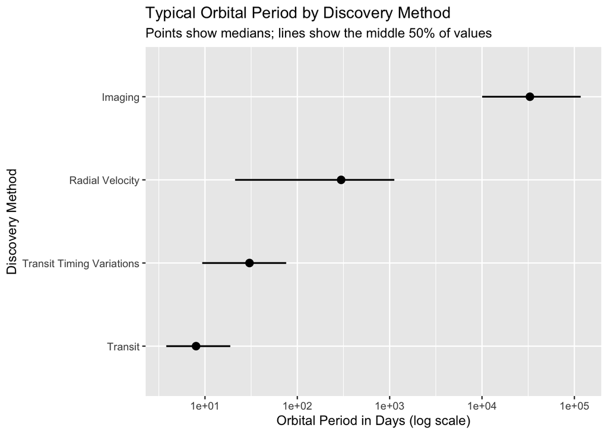

```r
ggplot(orbital_period_summary,
       aes(y = reorder(discoverymethod, median_value),
           x = median_value)) +
  geom_pointrange(aes(xmin = q1,
                      xmax = q3),
                  linewidth = 0.7) +
  scale_x_log10() +
  labs(
    title = "Typical Orbital Period by Discovery Method",
    subtitle = "Points show medians; lines show the middle 50% of values",
    x = "Orbital Period in Days (log scale)",
    y = "Discovery Method"
  )
```

The function makes it easy to reuse the same summary for another numeric variable later. In this result, transit discoveries tend to have much shorter orbital periods than imaging discoveries, which makes sense because transit surveys are better at repeatedly seeing planets that pass in front of their stars often.

**10. Use iteration to check data quality. For the variables `pl_rade`, `pl_bmasse`, `pl_orbper`, `pl_eqt`, `sy_dist`, `st_teff`, and `st_mass`, create a table and plot showing the percent of missing values in each variable.**

```r
important_vars <- c("pl_rade", "pl_bmasse", "pl_orbper",
                    "pl_eqt", "sy_dist", "st_teff", "st_mass")

missing_summary <- map_dfr(important_vars, function(var_name) {
  PSCD |>
    summarize(
      variable = var_name,
      missing_count = sum(is.na(.data[[var_name]])),
      percent_missing = 100 * mean(is.na(.data[[var_name]]))
    )
}) |>
  arrange(desc(percent_missing))

missing_summary |>
  kable(
    digits = 2,
    col.names = c("Variable", "Missing Count", "Percent Missing"),
    caption = "Missing values in selected exoplanet variables"
  )
```

Missing values in selected exoplanet variables

| Variable | Missing Count | Percent Missing |
| --- | --- | --- |
| pl_eqt | 1601 | 25.45 |
| pl_orbper | 340 | 5.40 |
| st_teff | 294 | 4.67 |
| pl_rade | 50 | 0.79 |
| pl_bmasse | 31 | 0.49 |
| sy_dist | 27 | 0.43 |
| st_mass | 9 | 0.14 |

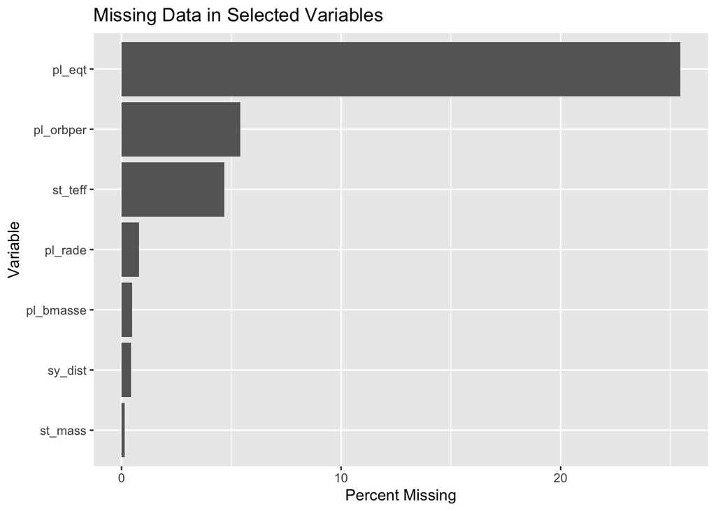

```r
ggplot(missing_summary,
       aes(x = percent_missing,
           y = reorder(variable, percent_missing))) +
  geom_col(fill = "gray40") +
  labs(
    title = "Missing Data in Selected Variables",
    x = "Percent Missing",
    y = "Variable"
  )
```

This check is important because not every exoplanet has every measurement available. For example, a variable with more missing data should be interpreted more carefully in later models or comparisons.

**11. Challenge question: Use simulation to test whether nearby planetary systems have a different proportion of single-star systems than expected by random chance. Define nearby systems as systems with `sy_dist` less than or equal to the median distance in the dataset.**

```r
distance_cutoff <- median(PSCD$sy_dist, na.rm = TRUE)

systems_with_distance <- PSCD |>
  filter(!is.na(sy_dist),
         !is.na(sy_snum))

nearby_systems <- systems_with_distance |>
  filter(sy_dist <= distance_cutoff)

observed_single_star_prop <- nearby_systems |>
  summarize(prop_single_star = mean(sy_snum == 1)) |>
  pull(prop_single_star)

simulate_single_star_prop <- function(star_count_pool, sample_size) {
  sampled_star_counts <- sample(star_count_pool,
                                size = sample_size,
                                replace = FALSE)

  mean(sampled_star_counts == 1)
}

set.seed(331)

simulated_single_star_props <- map_dbl(
  1:10000,
  ~ simulate_single_star_prop(systems_with_distance$sy_snum, nrow(nearby_systems))
)

simulation_results <- tibble(
  observed_nearby_prop = observed_single_star_prop,
  simulated_mean_prop = mean(simulated_single_star_props),
  lower_tail_p_value = (sum(simulated_single_star_props <= observed_single_star_prop) + 1) /
    (length(simulated_single_star_props) + 1)
)

simulation_results |>
  kable(
    digits = 4,
    col.names = c("Observed Nearby Proportion",
                  "Mean Simulated Proportion",
                  "Lower-Tail P-Value"),
    caption = "Simulation test for the proportion of nearby single-star systems"
  )
```

Simulation test for the proportion of nearby single-star systems

| Observed Nearby Proportion | Mean Simulated Proportion | Lower-Tail P-Value |
| --- | --- | --- |
| 0.8515 | 0.9104 | 1e-04 |

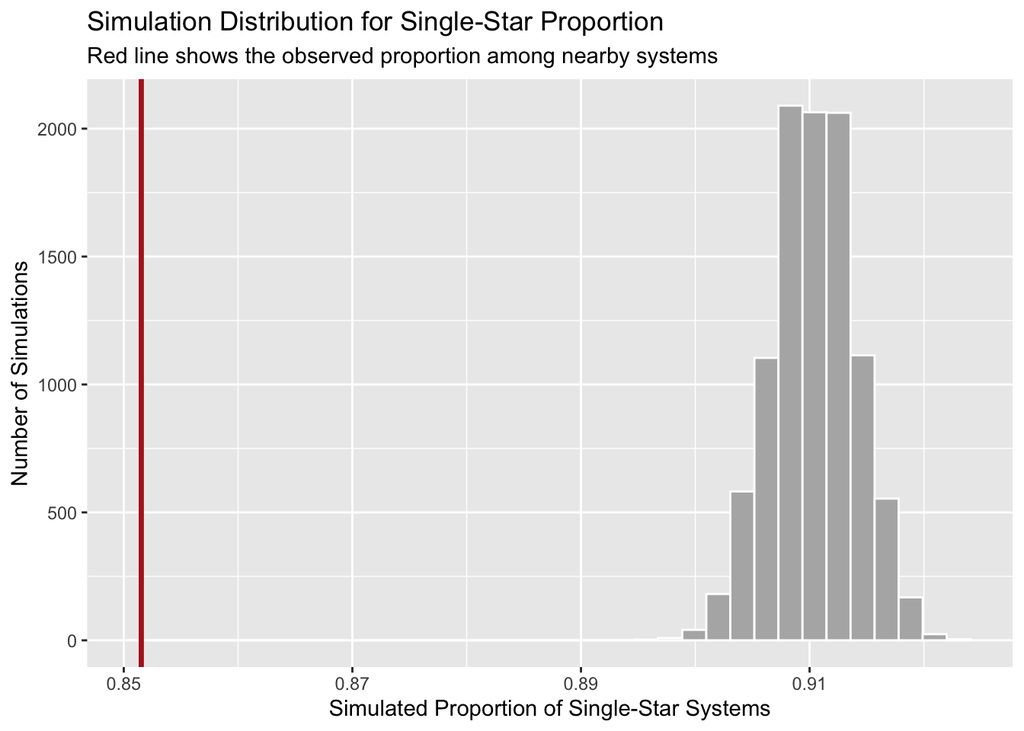

```r
tibble(prop_single_star = simulated_single_star_props) |>
  ggplot(aes(x = prop_single_star)) +
  geom_histogram(bins = 35,
                 fill = "gray70",
                 color = "white") +
  geom_vline(xintercept = observed_single_star_prop,
             color = "firebrick",
             linewidth = 1.2) +
  labs(
    title = "Simulation Distribution for Single-Star Proportion",
    subtitle = "Red line shows the observed proportion among nearby systems",
    x = "Simulated Proportion of Single-Star Systems",
    y = "Number of Simulations"
  )
```

The simulation compares the nearby systems to random samples of the same size from the full dataset. If the observed red line is far in the tail of the simulation distribution, then the nearby systems do not look like a random sample of the full dataset with respect to the number of stars in the system.

**12. Challenge question: Build a ranked table of the 10 most Earth-like and nearby planets using a custom scoring function. A lower score should mean the planet is closer to Earth radius, closer to 288 K, and closer to Earth.**

```r
score_rescale <- function(x) {
  if (!is.numeric(x)) {
    stop("Input must be numeric.")
  }

  x_range <- range(x, na.rm = TRUE)

  if (x_range[1] == x_range[2]) {
    return(rep(0, length(x)))
  }

  (x - x_range[1]) / (x_range[2] - x_range[1])
}

planet_rankings <- PSCD_candidate |>
  filter(!is.na(pl_rade),
         !is.na(pl_eqt),
         !is.na(sy_dist)) |>
  mutate(
    radius_difference = abs(pl_rade - 1),
    temp_difference = abs(pl_eqt - 288),
    radius_score = score_rescale(radius_difference),
    temp_score = score_rescale(temp_difference),
    distance_score = score_rescale(sy_dist),
    earth_like_score = radius_score + temp_score + distance_score
  ) |>
  arrange(earth_like_score) |>
  select(pl_name, hostname, discoverymethod, disc_year, pl_rade,
         pl_eqt, sy_dist, earth_like_score) |>
  slice_head(n = 10)

planet_rankings |>
  kable(
    digits = 3,
    col.names = c("Planet", "Host Star", "Discovery Method", "Discovery Year",
                  "Radius (Earth Radii)", "Equilibrium Temp (K)",
                  "Distance (Parsecs)", "Earth-Like Score"),
    caption = "Ten lowest-scoring planets using the custom Earth-like score"
  )
```

Ten lowest-scoring planets using the custom Earth-like score

| Planet | Host Star | Discovery Method | Discovery Year | Radius (Earth Radii) | Equilibrium Temp (K) | Distance (Parsecs) | Earth-Like Score |
| --- | --- | --- | --- | --- | --- | --- | --- |
| Teegarden’s Star b | Teegarden’s Star | Radial Velocity | 2019 | 1.050 | 277.0 | 3.831 | 0.005 |
| Ross 128 b | Ross 128 | Radial Velocity | 2017 | 1.110 | 301.0 | 3.375 | 0.007 |
| TRAPPIST-1 d | TRAPPIST-1 | Transit | 2016 | 0.788 | 286.2 | 12.430 | 0.009 |
| TOI-700 e | TOI-700 | Transit | 2023 | 0.953 | 272.9 | 31.126 | 0.010 |
| Gliese 12 b | Gliese 12 | Transit | 2024 | 0.930 | 314.6 | 12.210 | 0.011 |
| Proxima Cen d | Proxima Cen | Radial Velocity | 2025 | 0.692 | 282.0 | 1.301 | 0.011 |
| TOI-700 d | TOI-700 | Transit | 2020 | 1.073 | 268.8 | 31.126 | 0.012 |
| G 261-6 b | G 261-6 | Radial Velocity | 2025 | 1.100 | 322.3 | 10.627 | 0.014 |
| Wolf 1069 b | Wolf 1069 | Radial Velocity | 2023 | 1.080 | 250.1 | 9.583 | 0.014 |
| TRAPPIST-1 e | TRAPPIST-1 | Transit | 2017 | 0.920 | 249.7 | 12.430 | 0.014 |

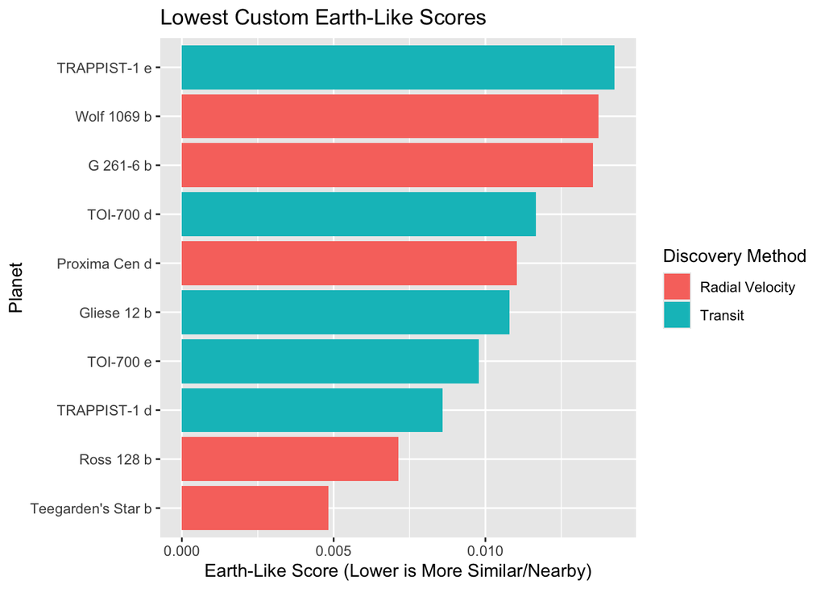

```r
ggplot(planet_rankings,
       aes(x = earth_like_score,
           y = reorder(pl_name, earth_like_score),
           fill = discoverymethod)) +
  geom_col() +
  labs(
    title = "Lowest Custom Earth-Like Scores",
    x = "Earth-Like Score (Lower is More Similar/Nearby)",
    y = "Planet"
  ) +
  guides(fill = guide_legend(title = "Discovery Method"))
```

## References

- NASA Exoplanet Archive. Planetary Systems Composite Parameters. https://exoplanetarchive.ipac.caltech.edu/cgi-bin/TblView/nph-tblView?app=ExoTbls&config=PSCompPars
- NASA Exoplanet Archive. Planetary Systems Composite Parameters column definitions. https://exoplanetarchive.ipac.caltech.edu/docs/API_PS_columns.html
- Tidyverse documentation for `dplyr`, `ggplot2`, `purrr`, and `tidyr`. https://www.tidyverse.org/packages/
- R documentation for base functions including `sample()`, `median()`, `quantile()`, and `range()`. https://www.r-project.org/other-docs.html